# Homework2

H.Pınar Yıldırım

07 05 2021

### Introduction

To fit a model to monthly first hand house sales data and predict future values I choosed variables CPI based exchanged rate, CPI value of houses, interest value for bank loans for housing and the survey questions statement on current financial situation and probability of saving in next year, expectation for wage change rate and probability of buying or building a house in next year as independent variables.

```r
library(tidyverse)
library(lubridate)
library(forecast)
library(zoo)
library(ggplot2)
library(dplyr)
library(data.table)
library(corrplot)


setwd("C:\\Users\\Pınar YILDIRIM\\Desktop")
house_sales =fread("house_sales.csv")
house_sales[,UNIXTIME:=NULL]
house_sales <- rename(house_sales, date=Tarih, sales=TP_AKONUTSAT3_TOPLAM,
                      cpibased_exchange_rate=TP_RK_T1_Y,cpi=TP_FG_J0, financial_situation=TP_TG2_Y11,
                      prob_of_saving=TP_TG2_Y12, wage_expectation=TP_TG2_Y16, prob_buy=TP_TG2_Y19, interest=TP_KTF12)
house_sales[,date:=ym(date)]
house_sales=house_sales[order(date)]
head(house_sales)
```

```
##          date sales cpibased_exchange_rate    cpi prob_buy wage_expectation
## 1: 2013-01-01 39163                 113.17 216.74 10.66789         90.02856
## 2: 2013-02-01 39521                 112.57 217.39 10.49400         89.26700
## 3: 2013-03-01 43052                 112.70 218.83 11.32500         89.46300
## 4: 2013-04-01 41233                 113.67 219.75 10.55893         89.56993
## 5: 2013-05-01 46049                 112.09 220.07 10.18300         91.35400
## 6: 2013-06-01 43345                 107.95 221.75 11.62400         91.06400
##    prob_of_saving financial_situation interest
## 1:       22.93490            75.43678   9.7750
## 2:       25.11500            75.03300   9.5775
## 3:       24.87400            74.61100   9.3060
## 4:       22.74748            76.12141   9.0575
## 5:       25.27200            76.79700   8.7660
## 6:       26.44100            75.96100   8.2975
```

## Target Variable Visualization

The target variable “house sales” looks like this and its histogram is similar to a normal distribution. Q-Q plot also supports normality assumption.

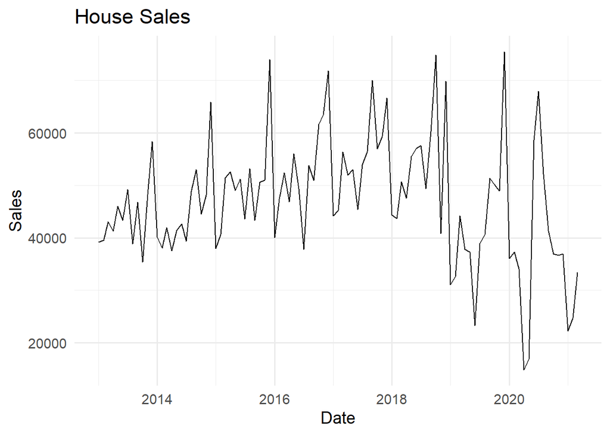

```r
ggplot(house_sales,aes(x=date,y=sales))+geom_line()+labs(y="Sales", x="Date", title="House Sales") + theme_minimal(base_size=14)
```

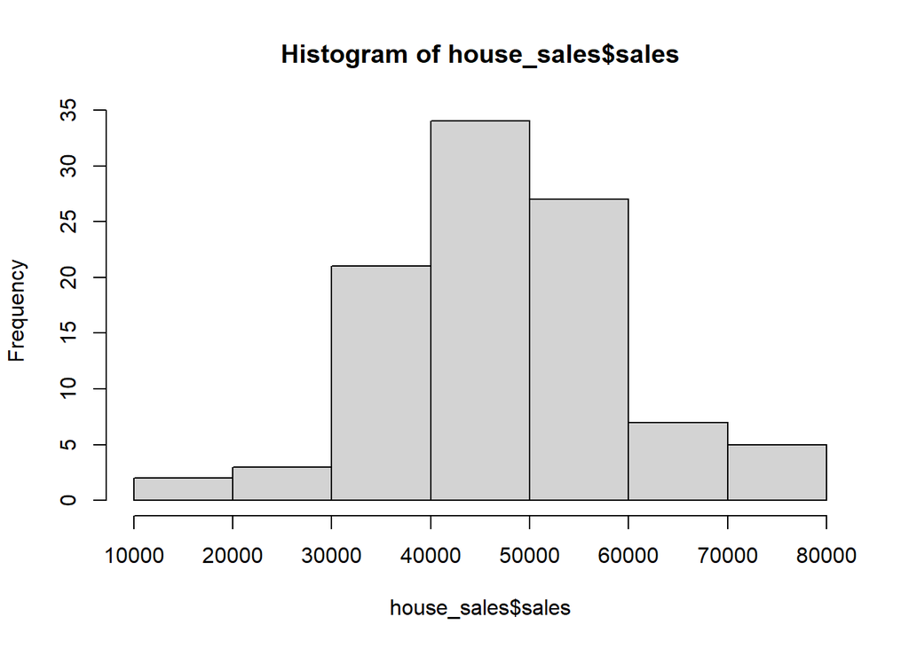

```r
hist(house_sales$sales)
```

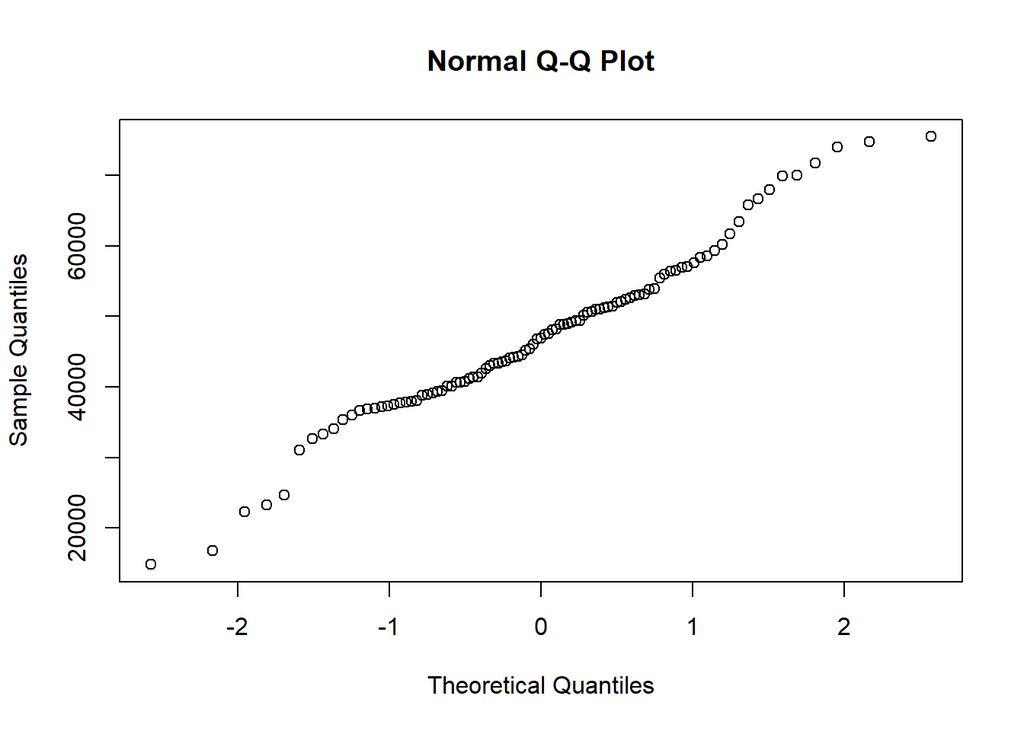

```r
qqnorm(house_sales$sales)
```

## Correlation and CCF

To check correlations and lagged correalations between independent variables and dependent variable I used corr function and ccf function

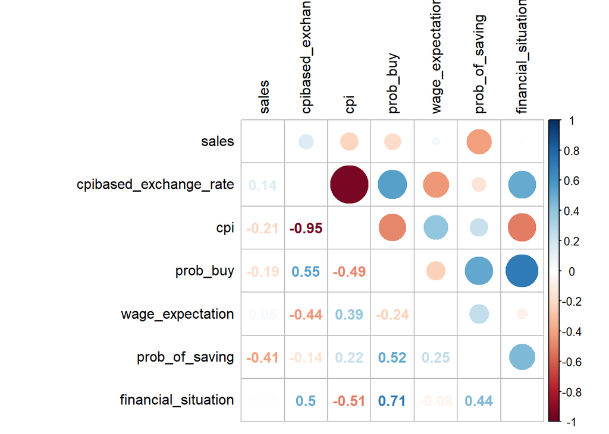

```r
cors<- cor(house_sales[,c(2,3,4,5,6,7,8)], use="pairwise.complete.obs")
corrplot.mixed(cors, tl.col="black", tl.pos = "lt")
```

House sales series does not show strong correlation with other series.

Some of the pairwise ccf functions show some significant lagged correlations.

CCF between house sales and exchange rate

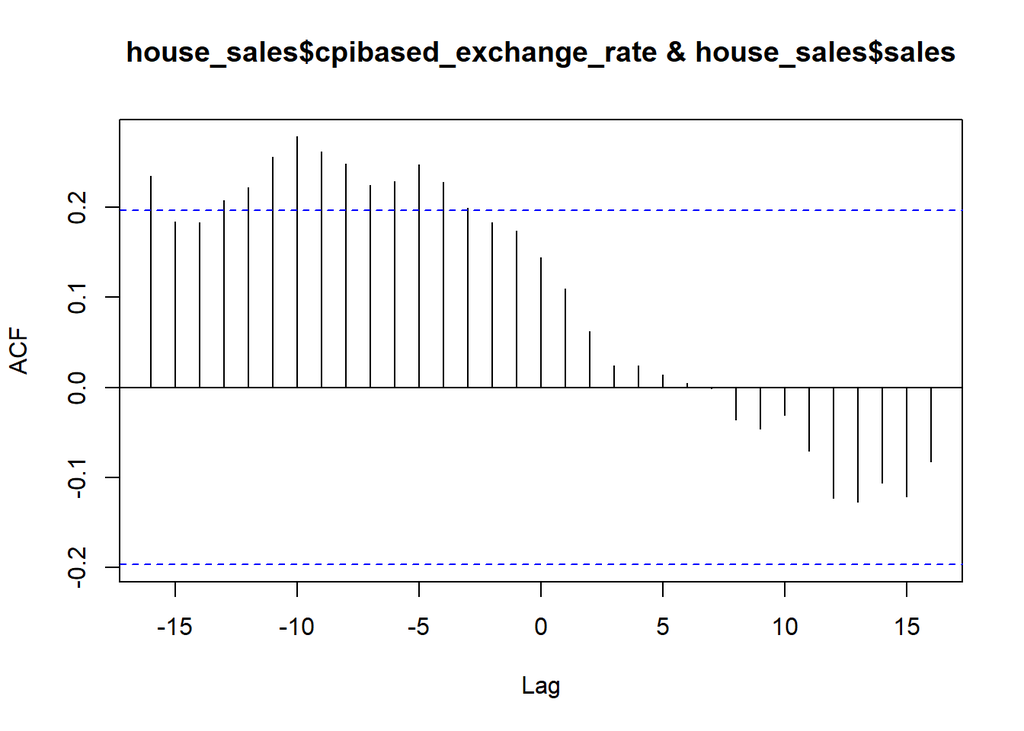

```r
ccf(house_sales$cpibased_exchange_rate,house_sales$sales)
```

CCF between house sales and CPI

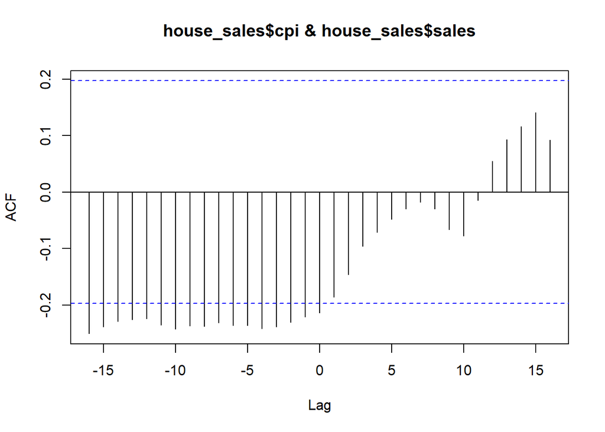

```r
ccf(house_sales$cpi,house_sales$sales,)
```

CCF between house sales and statement on financial situation

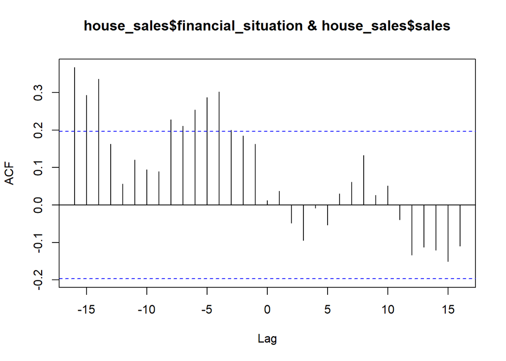

```r
ccf(house_sales$financial_situation,house_sales$sales,)
```

CCF between house sales and probability of saving

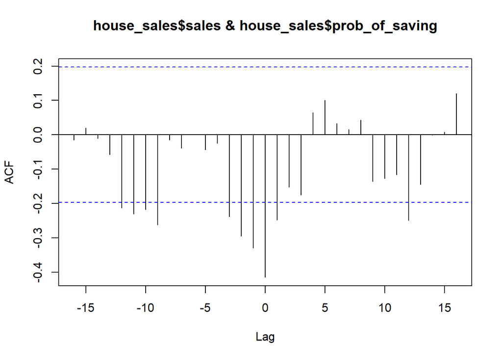

```r
ccf(house_sales$sales,house_sales$prob_of_saving)
```

CCF between house sales and wage expectation

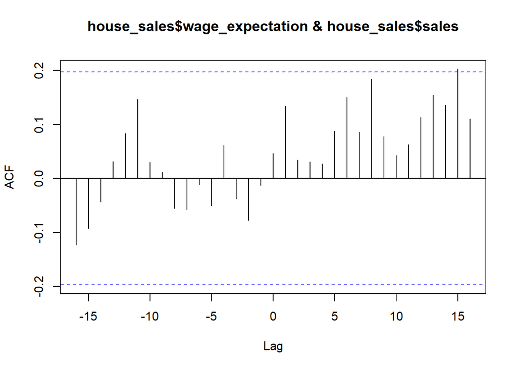

```r
ccf(house_sales$wage_expectation,house_sales$sales,)
```

CCF between house sales and probability of buying a house

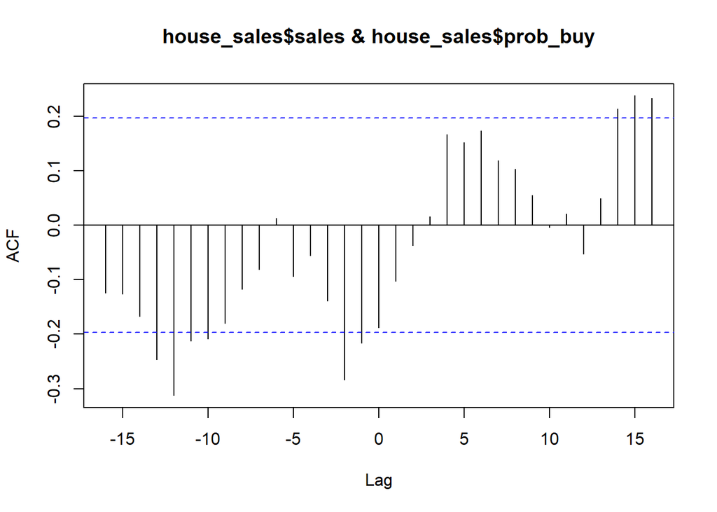

```r
ccf(house_sales$sales,house_sales$prob_buy)
```

CCF between house sales and interest rate

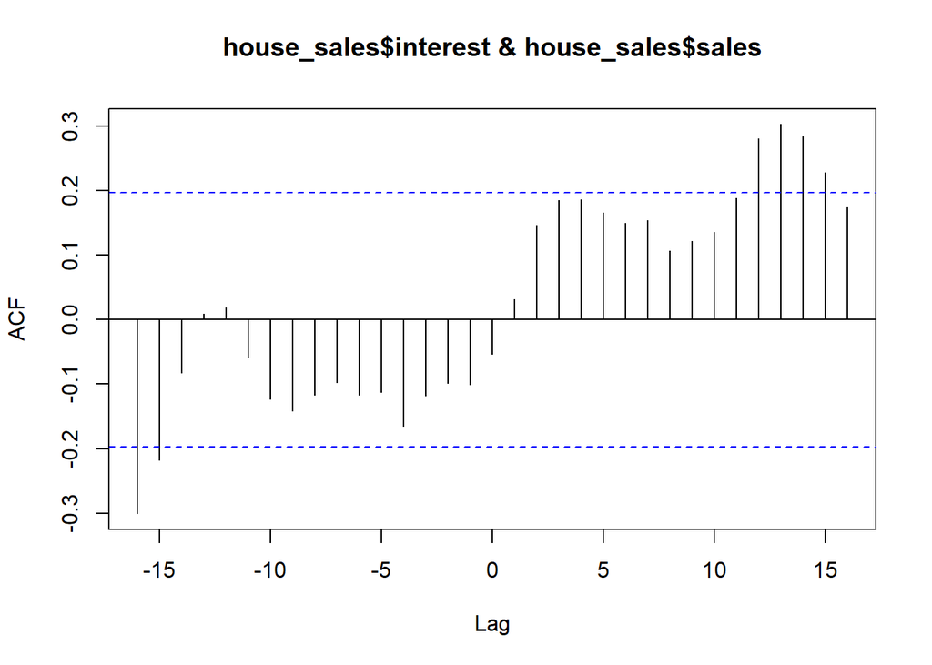

```r
ccf(house_sales$interest,house_sales$sales)
```

## Time Series Regression Model

Adding trend variable and constructing the first regression model.

```r
#TREND
house_sales[,trend:=1:.N]
hs_reg=lm(sales~trend,data=house_sales)
summary(hs_reg)
```

```
##
## Call:
## lm(formula = sales ~ trend, data = house_sales)
##
## Residuals:
##      Min       1Q   Median       3Q      Max
## -30755.8  -8347.5   -728.6   6103.4  29706.8
##
## Coefficients:
##             Estimate Std. Error t value Pr(>|t|)
## (Intercept) 49330.60    2395.58  20.592   <2e-16 ***
## trend         -42.35      41.60  -1.018    0.311
## ---
## Signif. codes:  0 '***' 0.001 '**' 0.01 '*' 0.05 '.' 0.1 ' ' 1
##
## Residual standard error: 11830 on 97 degrees of freedom
## Multiple R-squared:  0.01057,    Adjusted R-squared:  0.0003727
## F-statistic: 1.037 on 1 and 97 DF,  p-value: 0.3112
```

This is node a sufficient model.

But trend looks like this:

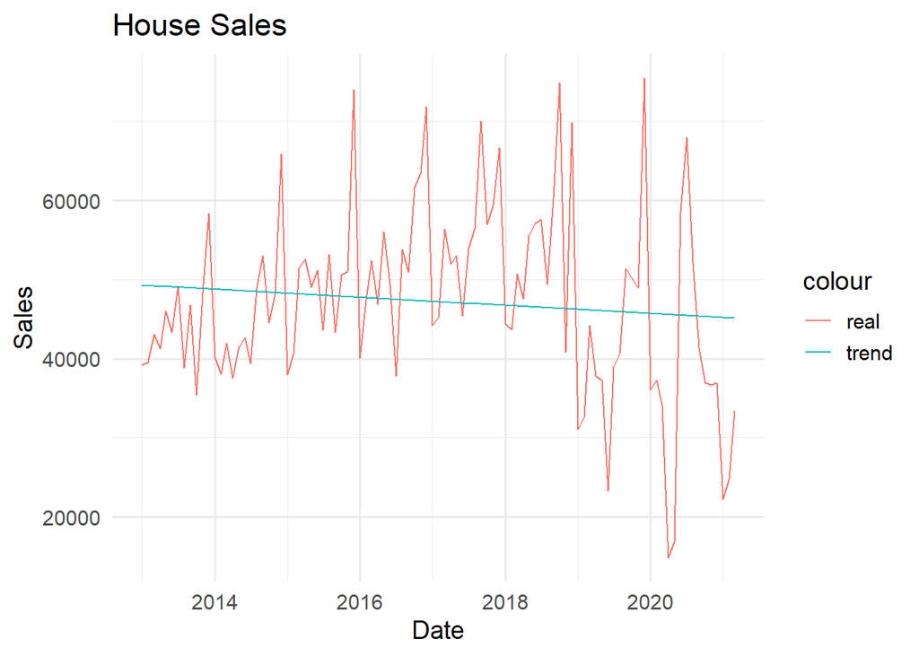

```r
house_sales[,trend_constant:=predict(hs_reg,house_sales)]
ggplot(house_sales ,aes(x=date)) +
  geom_line(aes(y=sales,color='real')) +
  geom_line(aes(y=trend_constant,color='trend'))+labs(y="Sales", x="Date", title="House Sales") + theme_minimal(base_size=14)
```

Adding months and year.

```r
#add months

house_sales[,month:=as.character(lubridate::month(date,label=T))]

#add year
house_sales[,year:=as.character(lubridate::year(date))]
```

```r
hs_regmy=lm(sales~trend+month+year,data=house_sales)
summary(hs_regmy)
```

```
##
## Call:
## lm(formula = sales ~ trend + month + year, data = house_sales)
##
## Residuals:
##      Min       1Q   Median       3Q      Max
## -19257.8  -2816.5   -163.2   3589.1  28083.0
##
## Coefficients: (1 not defined because of singularities)
##              Estimate Std. Error t value Pr(>|t|)
## (Intercept)  46368.42    3793.99  12.222  < 2e-16 ***
## trend         -120.96      57.29  -2.111 0.037893 *
## monthAra     16187.96    4114.97   3.934 0.000179 ***
## monthEki      2467.54    4110.19   0.600 0.549993
## monthEyl      3104.08    4108.99   0.755 0.452233
## monthHaz     -3035.54    4110.19  -0.739 0.462374
## monthKas       775.87    4112.18   0.189 0.850830
## monthMar     -2767.32    4005.53  -0.691 0.491669
## monthMay     -5129.25    4112.18  -1.247 0.215961
## monthNis     -8335.83    4114.97  -2.026 0.046169 *
## monthOca    -11039.24    4000.73  -2.759 0.007196 **
## monthŞub     -9366.94    4002.72  -2.340 0.021801 *
## monthTem      -718.58    4108.99  -0.175 0.861621
## year2014      2486.92    3212.40   0.774 0.441146
## year2015      8697.83    3214.11   2.706 0.008337 **
## year2016     12900.92    3359.56   3.840 0.000247 ***
## year2017     16686.75    3631.51   4.595 1.62e-05 ***
## year2018     17461.08    4004.28   4.361 3.87e-05 ***
## year2019      7255.08    4452.62   1.629 0.107210
## year2020      5211.42    4956.05   1.052 0.296223
## year2021           NA         NA      NA       NA
## ---
## Signif. codes:  0 '***' 0.001 '**' 0.01 '*' 0.05 '.' 0.1 ' ' 1
##
## Residual standard error: 8217 on 79 degrees of freedom
## Multiple R-squared:  0.6111, Adjusted R-squared:  0.5175
## F-statistic: 6.532 on 19 and 79 DF,  p-value: 8.935e-10
```

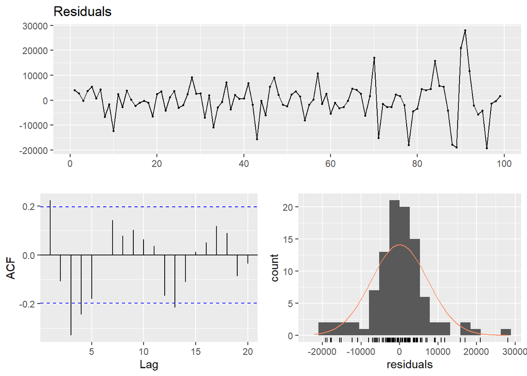

```
##
##  Breusch-Godfrey test for serial correlation of order up to 24
##
## data:  Residuals
## LM test = 54.301, df = 24, p-value = 0.0003885
```

```r
checkresiduals(hs_regmy)
```

P-Value is reduced but R-square value is not high.

There is lag 3 autocorrelation between residuals and variance is not constant.

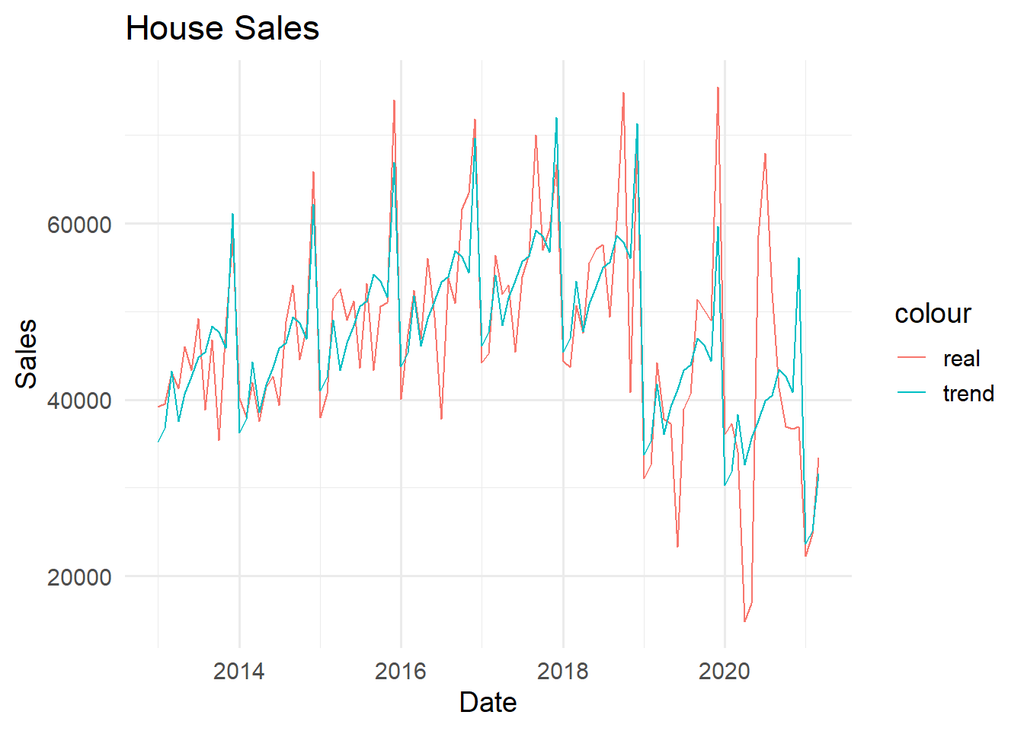

```r
house_sales[,trend_constant_my:=predict(hs_regmy,house_sales)]
ggplot(house_sales ,aes(x=date)) +
  geom_line(aes(y=sales,color='real')) +
  geom_line(aes(y=trend_constant_my,color='trend'))+labs(y="Sales", x="Date", title="House Sales") + theme_minimal(base_size=14)
```

## Adding Lagged Variables

As lagged variables I used lag 3 house sales, lag 1 interest rate, lag 10 exchange rate and lag 11 probability of buying a house.

```r
house_sales[,lag3:=lag(house_sales$sales,3)]
house_sales[,lag1int:=lag(interest,1)]
house_sales[,lag10exchange:=lag(cpibased_exchange_rate,10)]
house_sales[,lag11buy:=lag(prob_buy,11)]
```

```r
hs_regtry=lm(sales~trend+month+year+lag3+lag1int+lag10exchange+lag11buy,data=house_sales)
summary(hs_regtry)
```

```
##
## Call:
## lm(formula = sales ~ trend + month + year + lag3 + lag1int +
##     lag10exchange + lag11buy, data = house_sales)
##
## Residuals:
##      Min       1Q   Median       3Q      Max
## -20807.4  -2374.0   -414.2   3010.2  20134.2
##
## Coefficients: (1 not defined because of singularities)
##                 Estimate Std. Error t value Pr(>|t|)
## (Intercept)    1.450e+04  3.028e+04   0.479  0.63358
## trend          1.084e+02  1.593e+02   0.680  0.49864
## monthAra       1.819e+04  4.318e+03   4.213 8.06e-05 ***
## monthEki       4.315e+03  4.302e+03   1.003  0.31960
## monthEyl       2.220e+03  4.280e+03   0.519  0.60579
## monthHaz      -2.629e+03  4.327e+03  -0.607  0.54568
## monthKas       1.523e+03  4.383e+03   0.347  0.72948
## monthMar       2.790e+03  4.965e+03   0.562  0.57615
## monthMay      -7.870e+03  4.379e+03  -1.797  0.07699 .
## monthNis      -1.087e+04  4.456e+03  -2.440  0.01745 *
## monthOca      -9.632e+03  4.290e+03  -2.245  0.02822 *
## monthŞub      -8.248e+03  4.320e+03  -1.909  0.06069 .
## monthTem      -2.168e+03  4.363e+03  -0.497  0.62100
## year2014       8.180e+03  7.806e+03   1.048  0.29863
## year2015       1.311e+04  6.924e+03   1.894  0.06272 .
## year2016       1.743e+04  6.378e+03   2.734  0.00809 **
## year2017       1.938e+04  6.313e+03   3.070  0.00314 **
## year2018       2.379e+04  5.588e+03   4.257 6.91e-05 ***
## year2019       1.398e+04  5.083e+03   2.750  0.00773 **
## year2020       5.652e+03  5.626e+03   1.005  0.31888
## year2021              NA         NA      NA       NA
## lag3          -2.544e-01  1.182e-01  -2.153  0.03513 *
## lag1int       -5.446e+02  3.044e+02  -1.789  0.07836 .
## lag10exchange  4.021e+02  2.346e+02   1.714  0.09133 .
## lag11buy      -3.041e+02  8.961e+02  -0.339  0.73545
## ---
## Signif. codes:  0 '***' 0.001 '**' 0.01 '*' 0.05 '.' 0.1 ' ' 1
##
## Residual standard error: 7942 on 64 degrees of freedom
##   (11 observations deleted due to missingness)
## Multiple R-squared:  0.696,  Adjusted R-squared:  0.5867
## F-statistic:  6.37 on 23 and 64 DF,  p-value: 2.145e-09
```

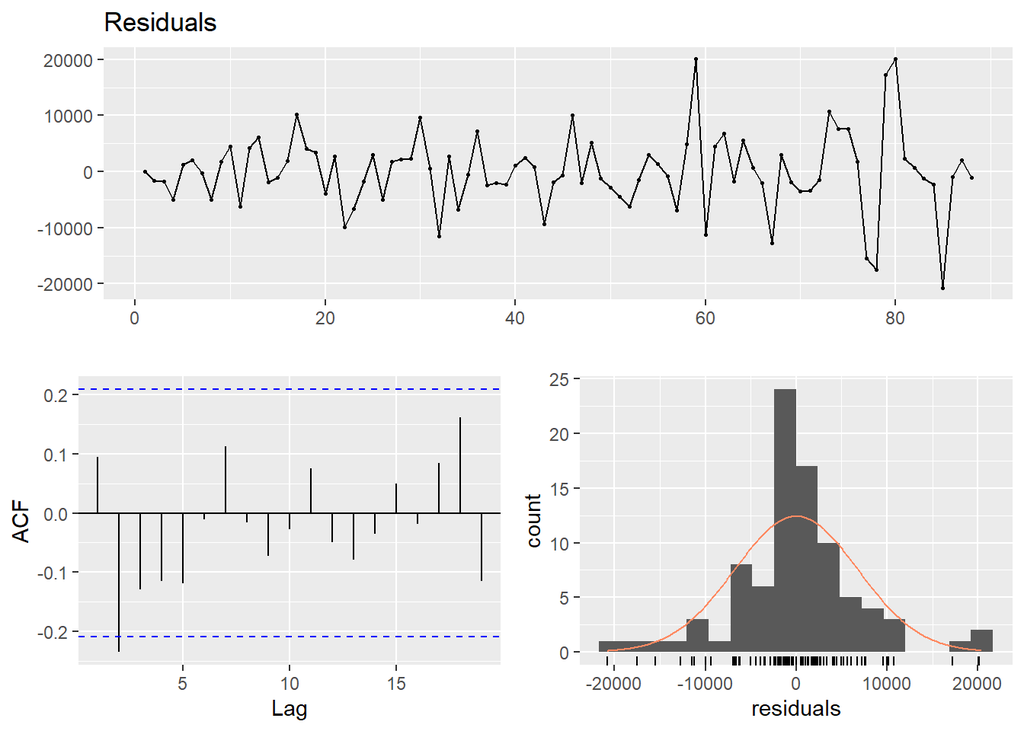

```
##
##  Breusch-Godfrey test for serial correlation of order up to 28
##
## data:  Residuals
## LM test = 55.642, df = 28, p-value = 0.001422
```

```r
checkresiduals(hs_regtry)
```

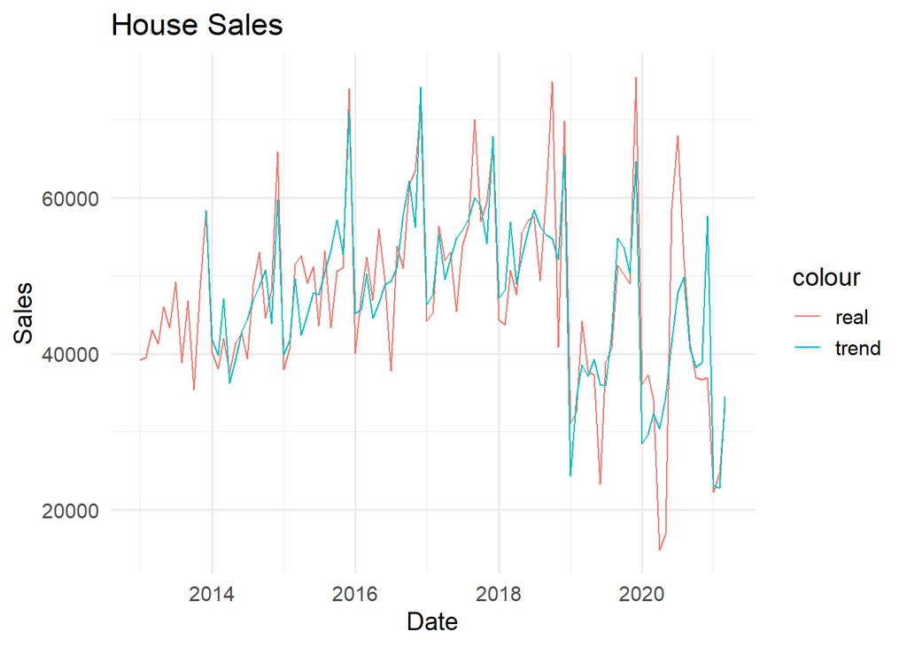

```r
house_sales[,trend_constant_try:=predict(hs_regtry,house_sales)]
ggplot(house_sales ,aes(x=date)) +
  geom_line(aes(y=sales,color='real')) +
  geom_line(aes(y=trend_constant_try,color='trend'))+labs(y="Sales", x="Date", title="House Sales") + theme_minimal(base_size=14)
```

## Getting the Forecast

Using the independent variables time series variables trend, months, years and lagged variables lag 3 house sales, lag 1 interest rate, lag 10 exchange rate and lag 11 probability of buying a house forecast for April 2021 is given below.

Seaonality in data is well understood but I can not identify additional variables to explain residuals. In 2020 and 2021 there are odd behaviours due to covid. There is steep decrease followed by steep increase in 2020 that my model is insufficient to explain.

```r
#get forecast
house_sales_pred=rbind(house_sales,data.table(date=ymd("2021-04-01")),fill=T)
house_sales_pred[,trend:=1:.N]
house_sales_pred[,month:=as.character(lubridate::month(date,label=T))]
house_sales_pred[,year:=as.character(lubridate::year(date))]
house_sales_pred[,lag3:=lag(sales,3)]
house_sales_pred[,lag1int:=lag(interest,1)]
house_sales_pred[,lag10exchange:=lag(cpibased_exchange_rate,10)]
house_sales_pred[,lag11buy:=lag(prob_buy,11)]

house_sales_pred[,predicted:=predict(hs_regtry,house_sales_pred)]

print("Forecast for 04-2021 is")
```

```
## [1] "Forecast for 04-2021 is"
```

```r
print(house_sales_pred[date=="2021-04-01",]$predicted)
```

```
## [1] 25012.96
```

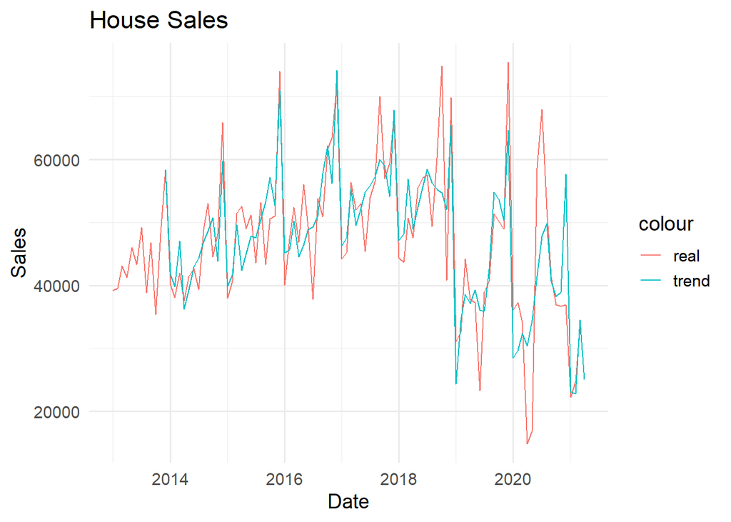

```r
ggplot(house_sales_pred ,aes(x=date)) +
  geom_line(aes(y=sales,color='real')) +
  geom_line(aes(y=predicted,color='trend'))+labs(y="Sales", x="Date", title="House Sales") + theme_minimal(base_size=14)
```